# wineQualityWhites_EDA

# Bivariate Analysis

### Talk about some of the relationships you observed in this part of the investigation. How did the feature(s) of interest vary with other features in the dataset?

- 酒的质量与酒精含量与酒的密度有很大关系，其中，酒精含量越高酒的质量往往越好，酒的密度越大酒的质量往往越差
- 同时酒精含量和酒的密度之间则是自然而然的反相关关系
- pH与非挥发性的酸之间有很大的相关性，酸性越强，pH越小，这是与我们的常识相符合的
- 新的变量二氧化硫的比例同样对酒的质量有一定的关系

### Did you observe any interesting relationships between the other features (not the main feature(s) of interest)?

剩余糖分与酒精含量之间竟然有一些负相关的关系

### What was the strongest relationship you found?

具有最强相关性的两个变量是剩余糖分和酒的密度

# Multivariate Plots Section

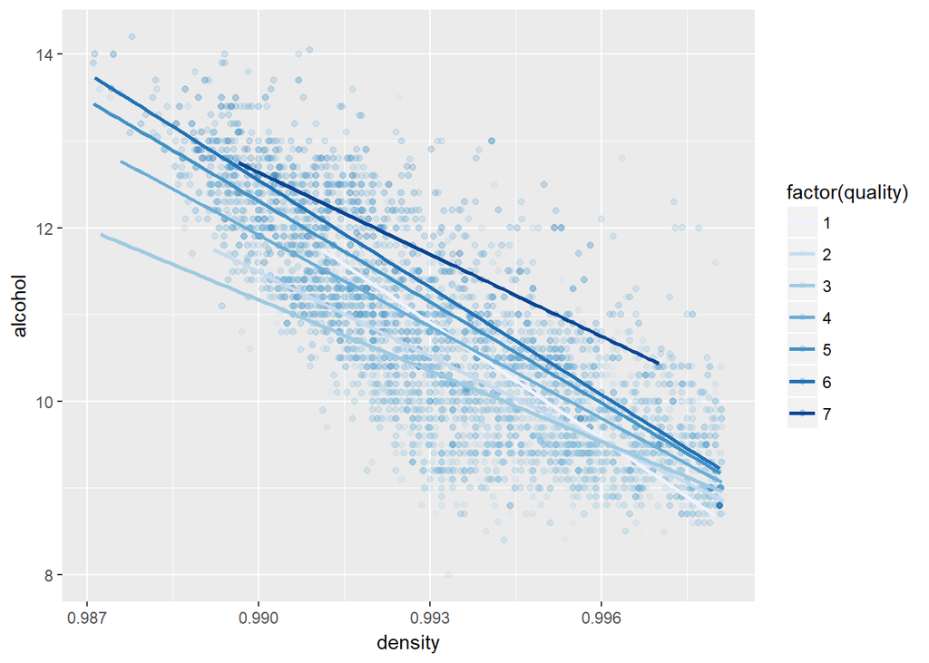

图中显示了不同quality的白葡萄酒，其酒精含量和密度的关系。可以看到对于所有质量的葡萄酒，密度和酒精含量几乎都是呈现出反相关的关系

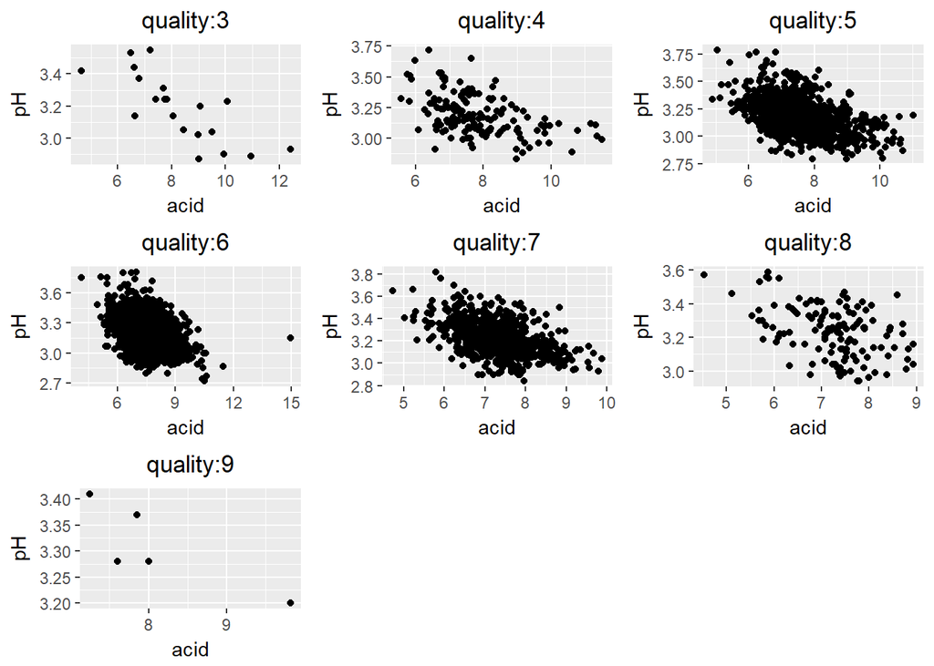

图中显示了不同quality的葡萄酒，其酸性物质的含量和pH的关系，可以看到对于所有quality的酒，其酸性物质的含量与pH都是呈现出反相关的关系，并且在quality为5、6、7的地方，两者的方差要大一些

[figure not shown]

图中画出了对于不同quality的酒其挥发性酸与非挥发性酸的关系，在图中并不能明显看出两种酸性物质的明确关系

```
##
## Calls:
## m1: lm(formula = I(quality) ~ I(alcohol), data = subset(wine, wine$density <
##     quantile(wine$density, 0.9)))
## m2: lm(formula = I(quality) ~ I(alcohol) + density, data = subset(wine,
##     wine$density < quantile(wine$density, 0.9)))
## m3: lm(formula = I(quality) ~ I(alcohol) + density + chlorides, data = subset(wine,
##     wine$density < quantile(wine$density, 0.9)))
## m4: lm(formula = I(quality) ~ I(alcohol) + density + chlorides +
##     acid_nor, data = subset(wine, wine$density < quantile(wine$density,
##     0.9)))
## m5: lm(formula = I(quality) ~ I(alcohol) + density + chlorides +
##     acid_nor + sulfur, data = subset(wine, wine$density < quantile(wine$density,
##     0.9)))
##
## ========================================================================================
##                        m1            m2            m3            m4            m5
## ----------------------------------------------------------------------------------------
##   (Intercept)         0.201       -16.523*      -15.499       -49.752***    -47.092***
##                      (0.106)       (7.935)       (7.940)       (8.117)       (8.014)
##   I(alcohol)          0.347***      0.374***      0.362***      0.414***      0.401***
##                      (0.010)       (0.016)       (0.017)       (0.017)       (0.017)
##   density                          16.549*       15.708*       50.353***     47.349***
##                                    (7.850)       (7.853)       (8.044)       (7.942)
##   chlorides                                      -1.494*       -1.301*       -1.412*
##                                                  (0.596)       (0.583)       (0.575)
##   acid_nor                                                     -0.933***     -0.776***
##                                                                (0.065)       (0.066)
##   sulfur                                                                      1.345***
##                                                                              (0.123)
## ----------------------------------------------------------------------------------------
##   R-squared           0.218         0.218         0.219         0.255         0.274
##   adj. R-squared      0.217         0.218         0.219         0.254         0.273
##   sigma               0.787         0.787         0.787         0.769         0.759
##   F                1224.134       614.767       412.432       375.625       332.580
##   p                   0.000         0.000         0.000         0.000         0.000
##   Log-likelihood  -5196.554     -5194.332     -5191.189     -5089.827     -5030.635
##   Deviance         2729.865      2727.112      2723.224      2600.737      2531.773
##   AIC             10399.108     10396.664     10392.379     10191.654     10075.270
##   BIC             10418.280     10422.226     10424.331     10229.997     10120.004
##   N                4405          4405          4405          4405          4405
## ========================================================================================
```

使用线性模型最终只解释了27.4%的方差，效果并不是很好 原因可能是各个变量之间的数值差别太大，尝试将所有变量标准化后再进行线性回归分析，以消除量纲的影响

```
##                      fixed.acidity volatile.acidity  citric.acid
## fixed.acidity           1.00000000      -0.02269729  0.289180698
## volatile.acidity       -0.02269729       1.00000000 -0.149471811
## citric.acid             0.28918070      -0.14947181  1.000000000
## residual.sugar          0.08902070       0.06428606  0.094211624
## chlorides               0.02308564       0.07051157  0.114364448
## free.sulfur.dioxide    -0.04939586      -0.09701194  0.094077221
## total.sulfur.dioxide    0.09106976       0.08926050  0.121130798
## density                 0.26533101       0.02711385  0.149502571
## pH                     -0.42585829      -0.03191537 -0.163748211
## sulphates              -0.01714299      -0.03572815  0.062330940
## alcohol                -0.12088112       0.06771794 -0.075728730
## quality                -0.11366283      -0.19472297 -0.009209091
## acid                    0.98717874       0.07157062  0.394143356
## acid_nor                0.85092911       0.50583144  0.170986037
## sugar_acid              0.11208572      -0.10530887  0.022546906
## sulfur                 -0.13945918      -0.19616085  0.016241396
##                      residual.sugar   chlorides free.sulfur.dioxide
## fixed.acidity            0.08902070  0.02308564       -0.0493958591
## volatile.acidity         0.06428606  0.07051157       -0.0970119393
## citric.acid              0.09421162  0.11436445        0.0940772210
## residual.sugar           1.00000000  0.08868454        0.2990983537
## chlorides                0.08868454  1.00000000        0.1013923521
## free.sulfur.dioxide      0.29909835  0.10139235        1.0000000000
## total.sulfur.dioxide     0.40143931  0.19891030        0.6155009650
## density                  0.83896645  0.25721132        0.2942104109
## pH                      -0.19413345 -0.09043946       -0.0006177961
## sulphates               -0.02666437  0.01676288        0.0592172458
## alcohol                 -0.45063122 -0.36018871       -0.2501039415
## quality                 -0.09757683 -0.20993441        0.0081580671
## acid                     0.10473749  0.04552987       -0.0451333172
## acid_nor                 0.11058884  0.05696746       -0.0935930610
## sugar_acid              -0.76428950 -0.04688074       -0.2888136640
## sulfur                   0.05142979 -0.03321768        0.7386321024
##                      total.sulfur.dioxide     density            pH
## fixed.acidity                 0.091069756  0.26533101 -0.4258582910
## volatile.acidity              0.089260504  0.02711385 -0.0319153683
## citric.acid                   0.121130798  0.14950257 -0.1637482114
## residual.sugar                0.401439311  0.83896645 -0.1941334540
## chlorides                     0.198910300  0.25721132 -0.0904394560
```

[output cut: 30 more lines]

```
## volatile.acidity      0.50583144 -0.1053088681 -0.19616085
## citric.acid           0.17098604  0.0225469064  0.01624140
## residual.sugar        0.11058884 -0.7642895014  0.05142979
## chlorides             0.05696746 -0.0468807358 -0.03321768
## free.sulfur.dioxide  -0.09359306 -0.2888136640  0.73863210
## total.sulfur.dioxide  0.12547885 -0.3690388081 -0.01344785
## density               0.24318814 -0.5716487284 -0.06552475
## pH                   -0.38422264  0.0548562103  0.00080129
## sulphates            -0.03356404 -0.0008598056 -0.02236186
## alcohol              -0.06872275  0.2583226123  0.06446642
## quality              -0.20038504 -0.0132640236  0.19721408
## acid                  0.88939608  0.0976389289 -0.15258717
## acid_nor              1.00000000  0.0413827320 -0.22339903
## sugar_acid            0.04138273  1.0000000000 -0.06075667
## sulfur               -0.22339903 -0.0607566732  1.00000000
```

标准化对相关系数没有任何的影响

```
##
## Calls:
## m6: lm(formula = I(quality) ~ I(alcohol), data = subset(wine_norm,
##     wine_norm$density < quantile(wine_norm$density, 0.9)))
## m7: lm(formula = I(quality) ~ I(alcohol) + density, data = subset(wine_norm,
##     wine_norm$density < quantile(wine_norm$density, 0.9)))
## m8: lm(formula = I(quality) ~ I(alcohol) + density + chlorides, data = subset(wine_norm,
##     wine_norm$density < quantile(wine_norm$density, 0.9)))
## m9: lm(formula = I(quality) ~ I(alcohol) + density + chlorides +
##     acid_nor, data = subset(wine_norm, wine_norm$density < quantile(wine_norm$density,
##     0.9)))
## m10: lm(formula = I(quality) ~ I(alcohol) + density + chlorides +
##     acid_nor + sulfur, data = subset(wine_norm, wine_norm$density <
##     quantile(wine_norm$density, 0.9)))
##
## ========================================================================================
##                        m6            m7            m8            m9           m10
## ----------------------------------------------------------------------------------------
##   (Intercept)         0.051        -4.153*       -3.896       -12.506***    -11.838***
##                      (0.027)       (1.995)       (1.996)       (2.040)       (2.014)
##   I(alcohol)          0.923***      0.994***      0.964***      1.101***      1.067***
##                      (0.026)       (0.043)       (0.044)       (0.044)       (0.044)
##   density                           4.135*        3.925*       12.583***     11.833***
##                                    (1.962)       (1.962)       (2.010)       (1.985)
##   chlorides                                      -0.019*       -0.017*       -0.018*
##                                                  (0.008)       (0.007)       (0.007)
##   acid_nor                                                     -0.189***     -0.157***
##                                                                (0.013)       (0.013)
##   sulfur                                                                      0.092***
##                                                                              (0.008)
## ----------------------------------------------------------------------------------------
##   R-squared           0.218         0.218         0.219         0.255         0.274
##   adj. R-squared      0.217         0.218         0.219         0.254         0.273
##   sigma               0.198         0.198         0.198         0.193         0.191
##   F                1224.134       614.767       412.432       375.625       332.580
##   p                   0.000         0.000         0.000         0.000         0.000
##   Log-likelihood    885.934       888.157       891.299       992.662      1051.854
##   Deviance          172.497       172.323       172.077       164.337       159.980
##   AIC             -1765.869     -1768.313     -1772.599     -1973.324     -2089.707
##   BIC             -1746.697     -1742.751     -1740.646     -1934.981     -2044.974
##   N                4405          4405          4405          4405          4405
## ========================================================================================
```

好吧，看来并没有什么影响

# Multivariate Analysis

### Talk about some of the relationships you observed in this part of the investigation. Were there features that strengthened each other in terms of looking at your feature(s) of interest?

根据相关系数表，我们可以看出两个比较重要的变量，一个是alcohol，一个是density，本身这两者之间是负相关的，它们两个看起来都是对我们感兴趣的变量quality有很大影响，但分析得知，alcohol和density本身就有很强的相关性，因此在做线性回归分析时才会看到在alcohol的基础上增加density对quality的预测影响不大

### OPTIONAL: Did you create any models with your dataset? Discuss the strengths and limitations of your model.

尝试构建线性回归模型，但R^2系数最高只有0.274，并不成功，推测原因可能是葡萄酒的预测模型并不适合线性模型

# Final Plots and Summary

### Plot One

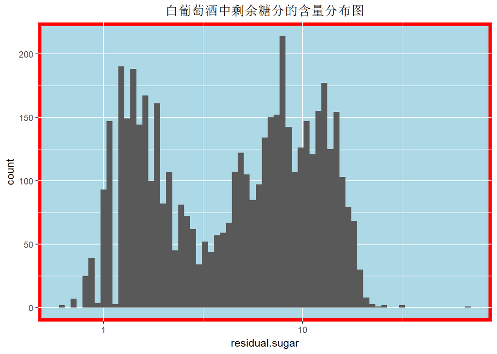

### Description One

白葡萄酒中的剩余糖分的含量是一个长尾类型的数据，将其横轴坐标对数化，可以看到两个峰和一个谷

### Plot Two

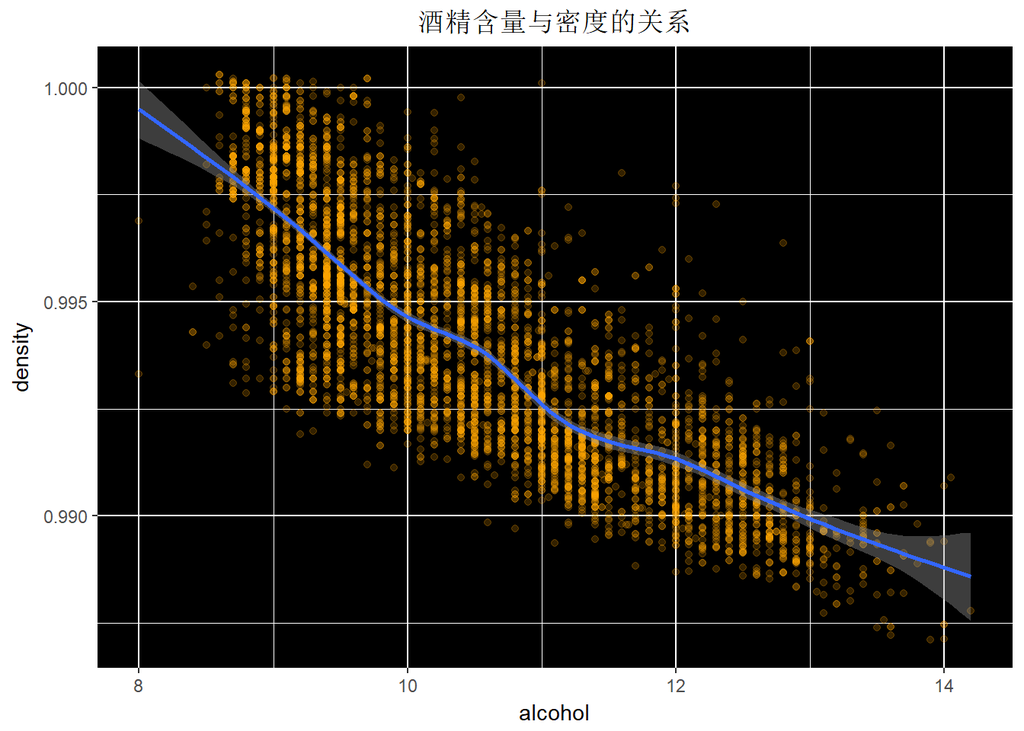

### Description Two

白葡萄酒中的酒精含量和密度呈现反比关系，即随着酒中的酒精含量的提高，酒的密度下降

### Plot Three

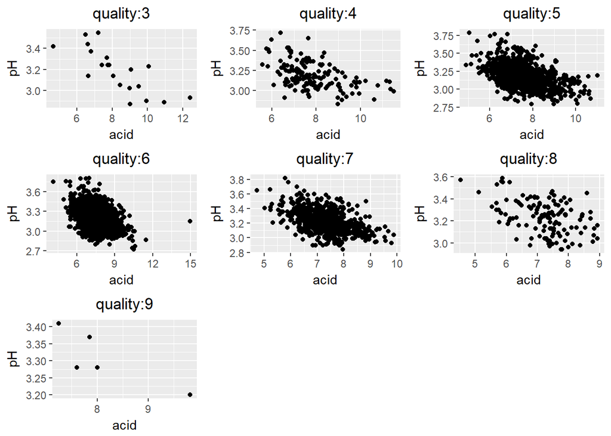

### Description Three

对于不同的酒的质量等级，酸度与pH的关系图，由图中可以看到，酸度与pH基本是呈现出反相关的关系，并且其方差很大

# Reflection

- 对于一个新的数据集来说，可能会有很多的变量，而其中很多变量都是与我们想要研究的内容没有很大关系的。我们进行单变量、双变量和多变量分析的目的就是为了找出对于我们想要研究的内容有关联的特征
- 特征与特征之间也有很大的相关性，比如本例中的alcohol和density两个变量，表面上看是与quality相关性最强的两个变量，然而实际上由于alcohol和density本身就有很强的相关性，它们两个对于quality的促进作用就没有表面上看起来这么大
- 可以由很多已有的变量来生成新的变量，例如本次项目中生成的两个新变量acid_nor和sulfur，对quality的影响要比原来的变量大一些
- 由于线性回归模型并没有起到很好的模拟作用，以后可以使用机器学习中的支持向量机、决策树等的方法对数据进行建模